# UK Police Stop and Search: A Study of Bias and Disproportionality

# 4.4 Gender bias

Aggregate gender information to form a data frame

```
##   gender  2020   2021   2022   2023 count_all_years
## 1 Female  4185  49590  46104  42836          142715
## 2   Male 39404 448247 398162 326848         1212661
## 3  Other   114   1280   1157   1778            4329
```

Calculate the absolute ratio of gender and add it to the data frame

```
##   gender  2020   2021   2022   2023 count_all_years prop_2020 prop_2021
## 1 Female  4185  49590  46104  42836          142715    9.576%    9.936%
## 2   Male 39404 448247 398162 326848         1212661   90.163%   89.808%
## 3  Other   114   1280   1157   1778            4329    0.261%    0.256%
##   prop_2022 prop_2023 prop_count_all_years
## 1   10.351%   11.532%              10.496%
## 2    89.39%    87.99%              89.186%
## 3     0.26%    0.479%               0.318%
```

Draw a dynamic line chart of the absolute probability of gender being searched year by year for dynamic analysis.

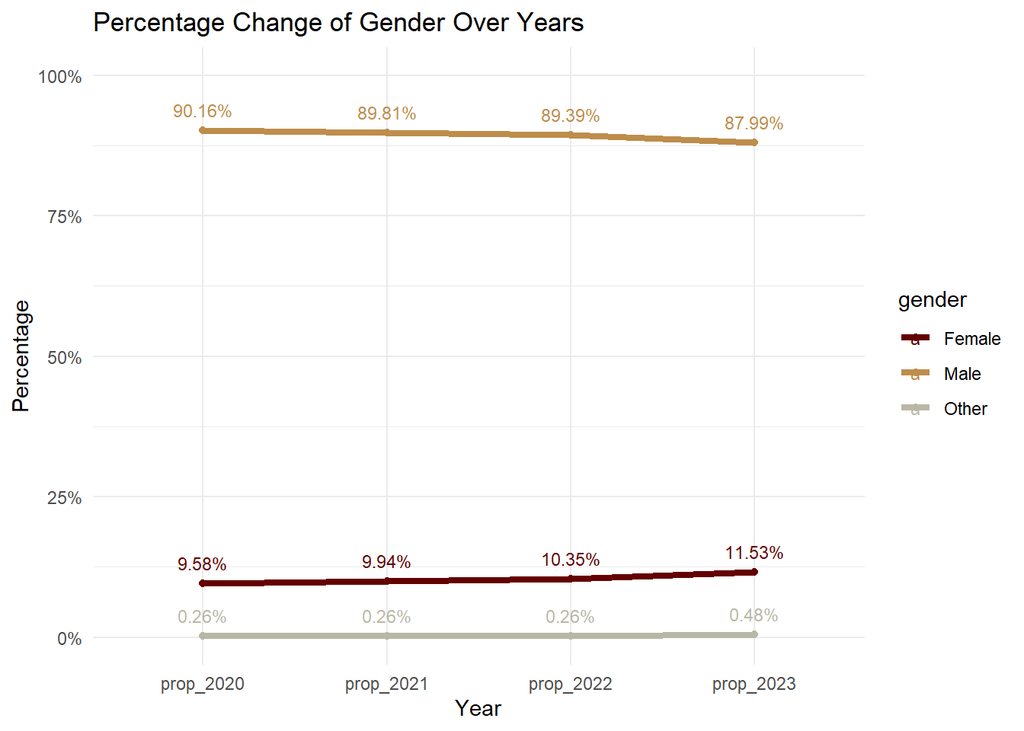

Use pie charts to plot the gender distribution of the total

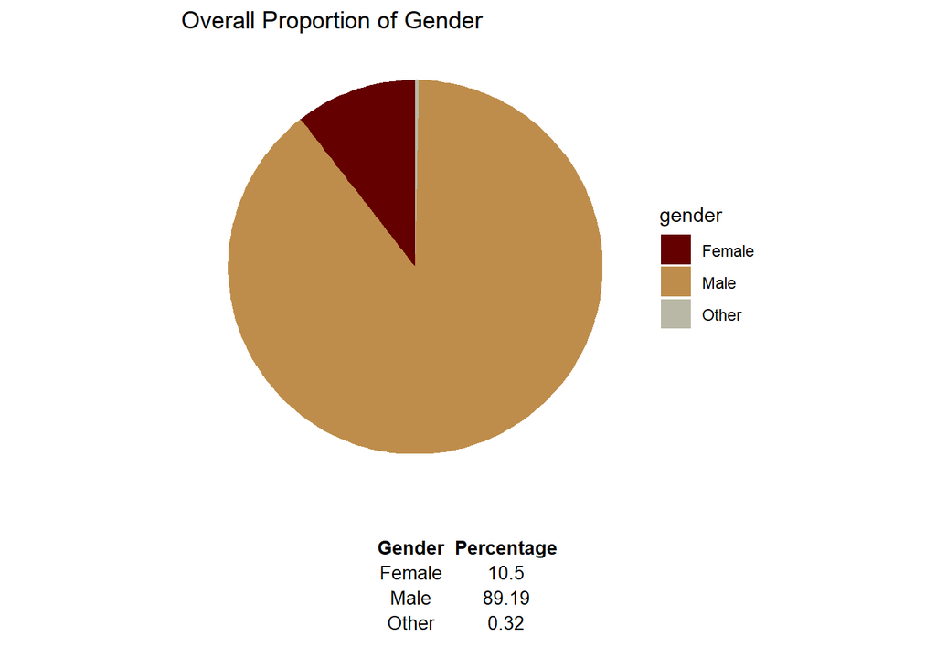

Use ONS data to calculate the proportion of searches by gender in the total population for relative proportion analysis

```
##   gender year_2023 total_population probability
## 1 Female     38705         34202325 0.001131648
## 2   Male    296265         33423721 0.008863914
```

Use a bar chart to observe the relative relationship between male and female gender search proportions

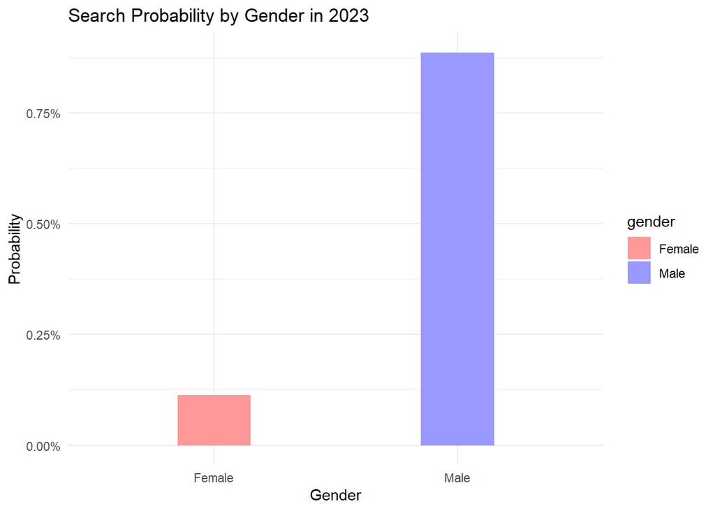

# Analysis for Gender:

From a gender perspective, according to the “percentage change of gender over years” and “overall proportion of gender” charts, males account for an average of 90% of search cases, though there has been a decline over three years. The “search probability by gender in 2023” chart still shows males at eight times the relative probability of females. Thus, we can conclude: males are subjected to a higher investigative bias than females.

# 4.5 Ethnicity bias

Process the source table to get the absolute number of searches for each race

```
##   officer_defined_ethnicity  2020   2021   2022   2023 count_all_years
## 1                     White 27020 296878 279119 237273          840290
## 2                     Black  8595 102024  85887  65599          262105
## 3                     Asian  6548  66037  54488  41971          169044
## 4                     Other  1460  16086  13417  12212           43175
## 5                     Mixed   158   1687   1012    805            3662
```

Take the calculated absolute proportions to each race and add them to the table

```
##   officer_defined_ethnicity  2020   2021   2022   2023 count_all_years
## 1                     White 27020 296878 279119 237273          840290
## 2                     Black  8595 102024  85887  65599          262105
## 3                     Asian  6548  66037  54488  41971          169044
## 4                     Other  1460  16086  13417  12212           43175
## 5                     Mixed   158   1687   1012    805            3662
##   prop_2020 prop_2021 prop_2022 prop_2023 prop_count_all_years
## 1   61.716%   61.502%   64.325%   66.303%              63.742%
## 2   19.632%   21.136%   19.793%   18.331%              19.882%
## 3   14.956%    13.68%   12.557%   11.728%              12.823%
## 4    3.335%    3.332%    3.092%    3.413%               3.275%
## 5    0.361%    0.349%    0.233%    0.225%               0.278%
```

Data aggregation to bring together information to create pie charts of absolute proportions required for gender

```
##   officer_defined_ethnicity prop_count_all_years
## 1                     White              0.63742
## 2                     Black              0.19882
## 3                     Asian              0.12823
## 4                     Other              0.03275
## 5                     Mixed              0.00278
```

Using the table information, draw a line chart to analyze the changes in the absolute proportion of searches of different races over the years.

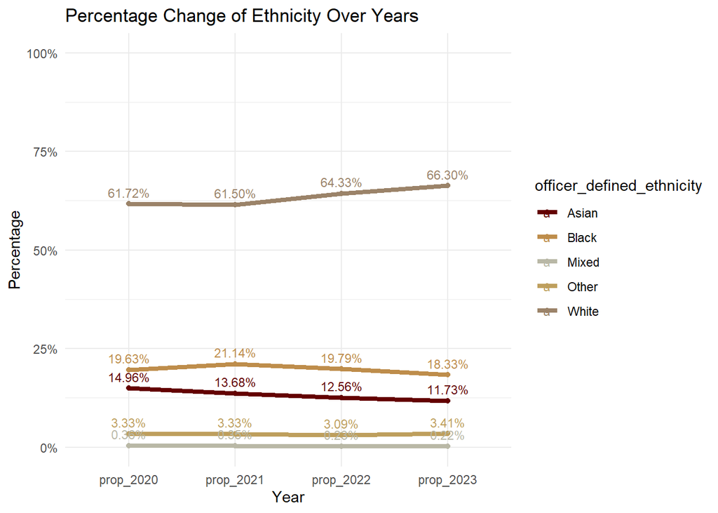

Using the table information, draw a pie chart to analyze the absolute proportion of searches for different races.

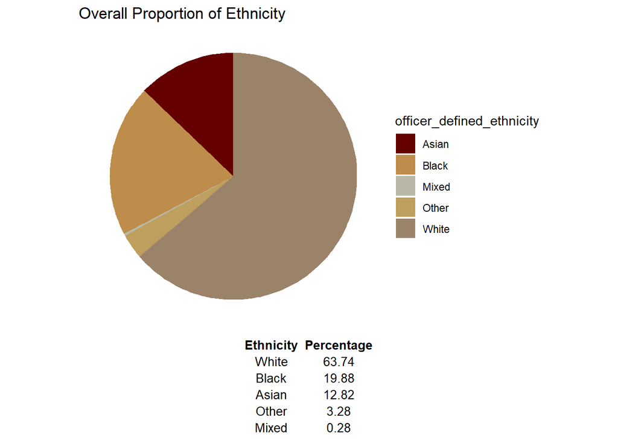

Import ONS data to obtain total population data of different ethnic groups in the UK

```
## # A tibble: 5 × 5
##   `Ethnic Group`                             `2011\r\n` `2021\r\n` `2011` `2021`
##   <chr>                                           <dbl>      <dbl>  <dbl>  <dbl>
## 1 Asian, Asian British or Asian Welsh           4213531    5515420    7.5    9.3
## 2 Black, Black British, Black Welsh, Caribb…    1864890    2409278    3.3    4
## 3 Mixed or Multiple ethnic groups               1224400    1717976    2.2    2.9
## 4 White                                        48209395   48699249   86     81.7
## 5 Other ethnic group                             563696    1255619    1      2.1
```

Create a mapping match between the two tables according to race names to obtain the relative search proportions of the total reference population of different races.

```
## # A tibble: 5 × 4
##   Ethnic_Group Population_2021 Search_Count_2021 Search_to_Population_Ratio
##   <chr>                  <dbl>             <int>                      <dbl>
## 1 Black                2409278            102024                   0.0423
## 2 Other                1255619             16086                   0.0128
## 3 Asian                5515420             66037                   0.0120
## 4 White               48699249            296878                   0.00610
## 5 Mixed                1717976              1687                   0.000982
```

Draw a distribution chart of the relative search rates of different races

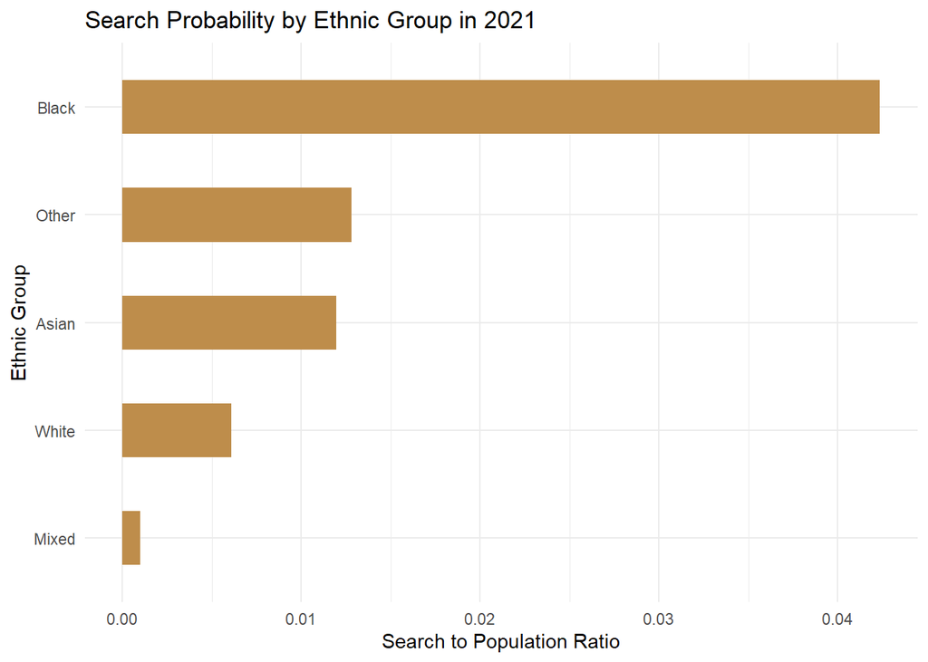